# Background

### The Multinomial Distribution

Before discussing LDA, we must understand the Dirichlet distribution. And before discussing the Dirichlet distribution, we must understand the multinomial distribution.

The multinomial (or categorical) distribution describes the number of counts expected from each outcome of an experiment repeated $n$ times. The simplest example is that of rolling a die, where the outcomes are 1 to 6. In this instance the probability of one number is the same as for any other. However, we can also imagine a scenario in which we have a weighted die, favouring higher values.

The multinomial distribution is described by two parameters: the number of trials ($n$) and the probability of each of the $k$ outcomes ($p_1,\ldots,p_k$, where $\sum p_i = 1$)

```python
import numpy as np
from scipy import stats

n = 100

# Equal probabilities
p = [1 / 6] * 6
equal = stats.multinomial(n, p).rvs(1000)
equal_mean = np.mean(equal, axis=0)
equal_std = np.std(equal, axis=0)

# Weighted probabilities
p = [0.1, 0.1, 0.1, 0.2, 0.2, 0.3]
weighted = stats.multinomial(n, p).rvs(1000)
weighted_mean = np.mean(weighted, axis=0)
weighted_std = np.std(weighted, axis=0)
```

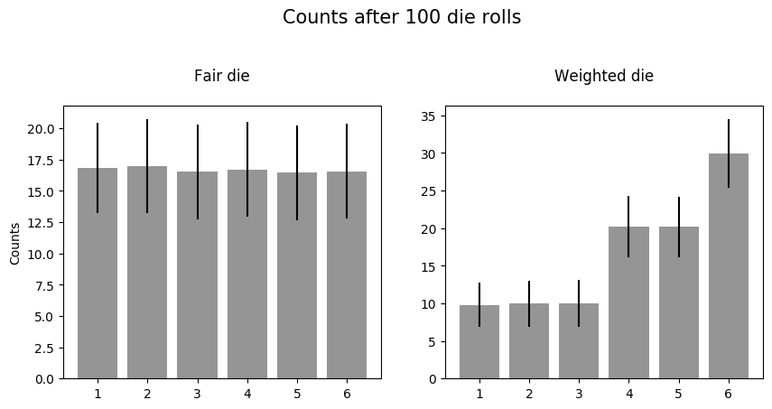

```python
%matplotlib inline
import matplotlib as mpl
import matplotlib.pyplot as plt
mpl.style.use('seaborn-deep')

x = np.arange(1,7)

fig, ax = plt.subplots(1, 2, figsize=(10, 4), dpi=100)
plt.suptitle("Counts after 100 die rolls", fontsize=15, x=0.5, y=1.15)
ax[0].bar(x, equal_mean, yerr=equal_std, color=plt.cm.Greys(0.5))
ax[0].set_title('Fair die', pad=20)
ax[0].set_ylabel('Counts')

ax[1].bar(x, weighted_mean, yerr=weighted_std, color=plt.cm.Greys(0.5))
ax[1].set_title('Weighted die', pad=20);
```

### The Dirichlet Distribution

In the above graphs we can see how the probabilities ($p$) given to the multinomial distribution affect the expected outcomes of the trials. Here we knew the exact probabilities of the fair and weighted die, though in practice we may only have a vague knowledge of their values. Therefore, to accurately model the expected values of given die's roll, we also need a probability distribution of the values for $p$, and this is what we can achieve using the Dirichlet distribution. One can see a hierarchy of sorts between the Dirichlet and multinomial distribution, where the Dirichlet distribes the probabilities of the parameter space which then defines the multinomial model (i.e. the probabilities of the die's roll).$^*$

For $K$ categories (or die outcomes in the current scenario), the Dirichlet distribution takes $\alpha_1,\ldots,\alpha_K$ as parameters and will return $p_1,\ldots,p_K$. [This article](http://blog.bogatron.net/blog/2014/02/02/visualizing-dirichlet-distributions/) by Thomas Boggs gives a good visualisation for the exact meaning of $\alpha$. All that's important to know for now is that if 1.0 is assigned to all values of $\alpha$, the chosen values for $p$ are uniformly sampled from the probability space (read Thomas' article for a more clear description of what this means). That is, we are equally likely to return $p=(0.05,\ 0.05,\ 0.05,\ 0.05,\ 0.05,\ 0.75)$ as $p=(0.2,\ 0.1,\ 0.2,\ 0.2,\ 0.2,\ 0.1)$. $\alpha < 1.0$ results in probabilities skewed to a single outcome, such as $p=(0.98,\ 0.004,\ 0.004,\ 0.004,\ 0.004,\ 0.004)$. $\alpha$ greater than 1.0 favours a more equal weighting of probabilities between categories - $p=(0.2,\ 0.2,\ 0.2,\ 0.2,\ 0.2,\ 0.2)$.

<sub>$^*$As an aside, this hierarchy is common to Bayesian inference, where we must know the likelihood of a parameter given the data, as well as the probability of observing that parameter. The Dirichlet is said to be conjugate to the multinomial distribution, which means that this Bayesian posterior distribution can be solved for in closed form (a useful, though increasingly less necessary quality).</sub>

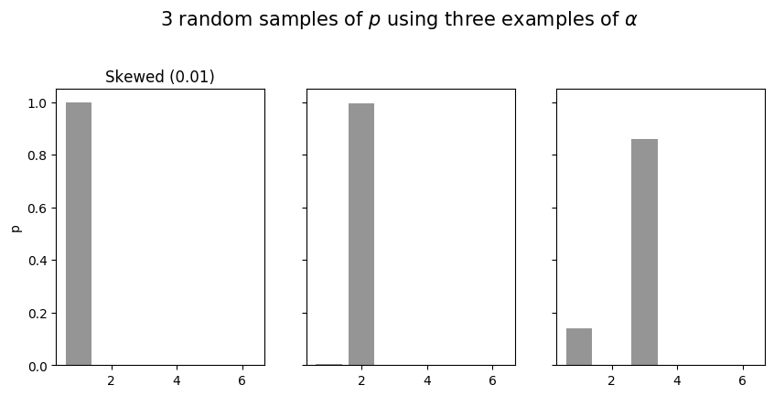

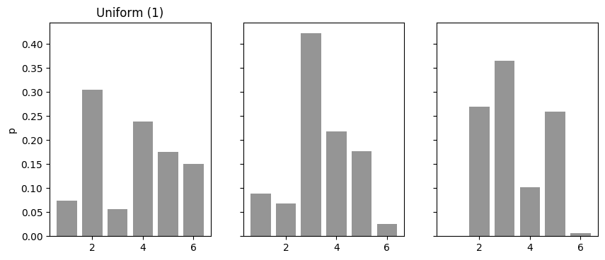

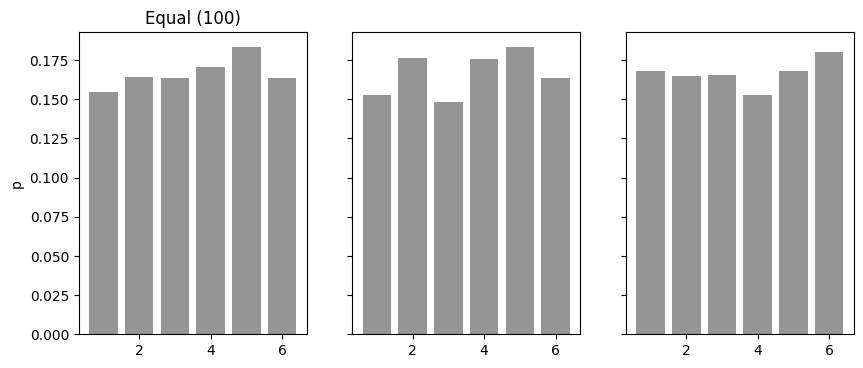

```python
# Create values of p skewed to a single category
skewed_alpha = [0.01, 0.01, 0.01, 0.01, 0.01, 0.01]
skewed_p = stats.dirichlet(skewed_alpha).rvs(3)

fig, axes = plt.subplots(1, 3, figsize=(10, 4), dpi=100, sharex=True, sharey=True)
plt.suptitle("3 random samples of $p$ using three examples of $\\alpha$", fontsize=15, x=0.5, y=1.1)
axes[0].set_title("Skewed (0.01)")
axes[0].set_ylabel('p')
for ax, p in zip(axes, skewed_p):
    ax.bar(x, p, color=plt.cm.Greys(0.5))

# Create values of p described by a uniform distribution
uniform_alpha = [1, 1, 1, 1, 1, 1]
uniform_p = stats.dirichlet(uniform_alpha).rvs(3)

fig, axes = plt.subplots(1, 3, figsize=(10, 4), dpi=100, sharey=True)
axes[0].set_title("Uniform (1)")
axes[0].set_ylabel('p')
for ax, p in zip(axes, uniform_p):
    ax.bar(x, p, color=plt.cm.Greys(0.5))

# Create values of p equal in weighting
equal_alpha = [100, 100, 100, 100, 100, 100]
equal_p = stats.dirichlet(equal_alpha).rvs(3)

fig, axes = plt.subplots(1, 3, figsize=(10, 4), dpi=100, sharey=True)
axes[0].set_title("Equal (100)")
axes[0].set_ylabel('p')
for ax, p in zip(axes, equal_p):
    ax.bar(x, p, color=plt.cm.Greys(0.5))
```

The above only considers scenarios with an equal weighting of $\alpha$ to all $K$. As you might expect, if we increase the value of $\alpha$ for a single value of $K$, then the expected value of $p$ will also increase. Below, we will repeat these rolls but with a die biased towards the value 6.

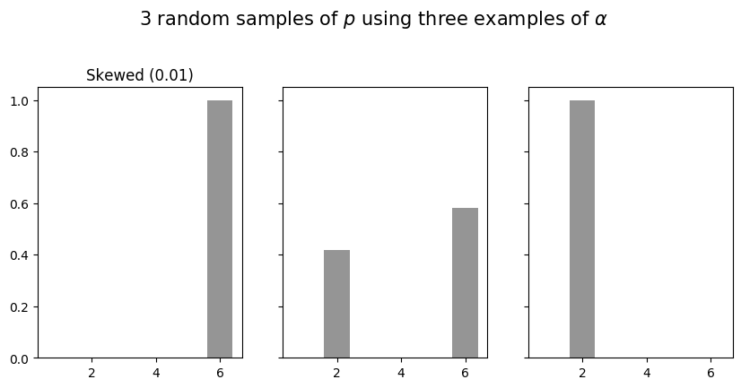

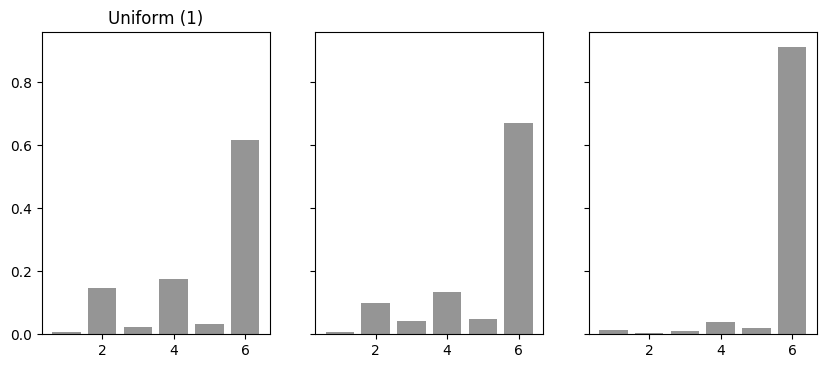

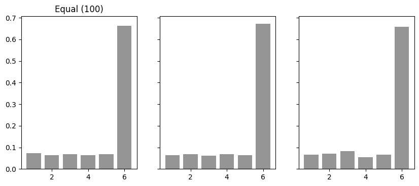

```python
skewed_alpha = [0.01, 0.01, 0.01, 0.01, 0.01, 0.1]
skewed_p = stats.dirichlet(skewed_alpha).rvs(3)

fig, axes = plt.subplots(1, 3, figsize=(10, 4), dpi=100, sharey=True)
plt.suptitle("3 random samples of $p$ using three examples of $\\alpha$", fontsize=15, x=0.5, y=1.1)
axes[0].set_title("Skewed (0.01)")
for ax, p in zip(axes, skewed_p):
    ax.bar(x, p, color=plt.cm.Greys(0.5))

uniform_alpha = [1, 1, 1, 1, 1, 10]
uniform_p = stats.dirichlet(uniform_alpha).rvs(3)

fig, axes = plt.subplots(1, 3, figsize=(10, 4), dpi=100, sharey=True)
axes[0].set_title("Uniform (1)")
for ax, p in zip(axes, uniform_p):
    ax.bar(x, p, color=plt.cm.Greys(0.5))

equal_alpha = [100, 100, 100, 100, 100, 1000]
equal_p = stats.dirichlet(equal_alpha).rvs(3)

fig, axes = plt.subplots(1, 3, figsize=(10, 4), dpi=100, sharey=True)
axes[0].set_title("Equal (100)")
for ax, p in zip(axes, equal_p):
    ax.bar(x, p, color=plt.cm.Greys(0.5))
```

Hopefully, these simple examples give you a decent intuition for how the Dirichlet and multinomial distributions are related. I encorouage you to play around with the code to help reinforce this concept.